# Problem 1 - Simple Lattice Method

# Downwash Calculation

Out next step is to calculate the downwash affecting our wing at different points along the span. Downwash is directly related to our circulation data above, as we took the derivative of the circulation in an effort to calculate the induced angle of attack. Now that we have our induced angle of attack, we can use this value, in combination with our Vinf or freestream speed in order to calculate the downwash distribution over the span of our wing.

[figure not shown]

The diagram above shows the relationship that we used to calculate our effective angle of attack. This diagram also provides us with the information to calculate our downwash w. We can do this pretty simply using the following equation

$$ W(y) = - V_{\infty} * \alpha_{i}(y) $$

> Now that we have our equations and our $\alpha_{i}$ we can calculate and plot the downwash as a function of our wing span. Let do this calculaton and then plot the results. Similar to the above plot for effective angle of attack, implement the above equation and then plot the downwash for both planforms on the same plot.

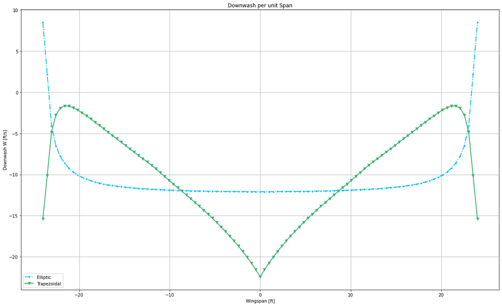

Our effective angles of attack are slightly different for each planform. Our effective angle of attack for the trapezoidal wing is a minimum at the root of the wing and steadily increases approaching our base angle of attack of 7 degrees. However, at the tips of the wing, the effective angle of attack drops in magnitude. In other words, the tips of the trapezoidal wing are at a lower angle of attack than further in on the wing. This means that the region of the wing near the tips will stall before the root does, and the stall will slowly creep inward toward the root of the wing as the angle of attack increases. The elliptic wing in comparison is mostly constant and will stall at the tips first, having a minimal effect on the wing. This also means that the wing will stall all at once, rather than gradually.